# Simulated Data Summary, version 1

Eric Archer

12/4/2016

The data was generated with a combination of a fastsimcoal simulation followed by an rmetasim simulation initialized with the allele frequencies derived from fastsimcoal.

## Scenario parameters

The simulated scenarios are derived from combinations of the following parameter values:

```r
num.pops <- 5
num.loci <- 1000
div.time <- 100000
Ne <- c(50, 500)
Nm <- c(0, 1, 5)
theta <- c(0.1, 0.25)
```

These produce the following data.frame of scenario parameters:

```
   scenario  Ne Nm theta num.loci mig.rate mut.rate        Fst div.time
1         1  50  0  0.10     1000    0.000 0.000500 1.00000000    1e+05
2         2 500  0  0.10     1000    0.000 0.000050 1.00000000    1e+05
3         3  50  1  0.10     1000    0.020 0.000500 0.20000000    1e+05
4         4 500  1  0.10     1000    0.002 0.000050 0.20000000    1e+05
5         5  50  5  0.10     1000    0.100 0.000500 0.04761905    1e+05
6         6 500  5  0.10     1000    0.010 0.000050 0.04761905    1e+05
7         7  50  0  0.25     1000    0.000 0.001250 1.00000000    1e+05
8         8 500  0  0.25     1000    0.000 0.000125 1.00000000    1e+05
9         9  50  1  0.25     1000    0.020 0.001250 0.20000000    1e+05
10       10 500  1  0.25     1000    0.002 0.000125 0.20000000    1e+05
11       11  50  5  0.25     1000    0.100 0.001250 0.04761905    1e+05
12       12 500  5  0.25     1000    0.010 0.000125 0.04761905    1e+05
   num.pops
1         5
2         5
3         5
4         5
5         5
6         5
7         5
8         5
9         5
10        5
11        5
12        5
```

For each scenario, two types of migration structures were simulated, “island” (for scenario 3):

[output not shown]

and “stepping.stone”:

```
     [,1] [,2] [,3] [,4] [,5]
[1,] 0.98 0.02 0.00 0.00 0.00
[2,] 0.02 0.96 0.02 0.00 0.00
[3,] 0.00 0.02 0.96 0.02 0.00
[4,] 0.00 0.00 0.02 0.96 0.02
[5,] 0.00 0.00 0.00 0.02 0.98
```

## Equilibirum tests

To ensure that the selected divergence time was sufficiently long to establish mutation/migration/drift equilibrium, I ran 3 fastsimcoal replicates of each scenario at divergence times of 1, 5, 10, 50, 100, 500, 1000, 5000, and 10000 generations. Here is an example distribution of Fst and observed heterozygosity for Scenario 3 with the stepping.stone migration matrix:

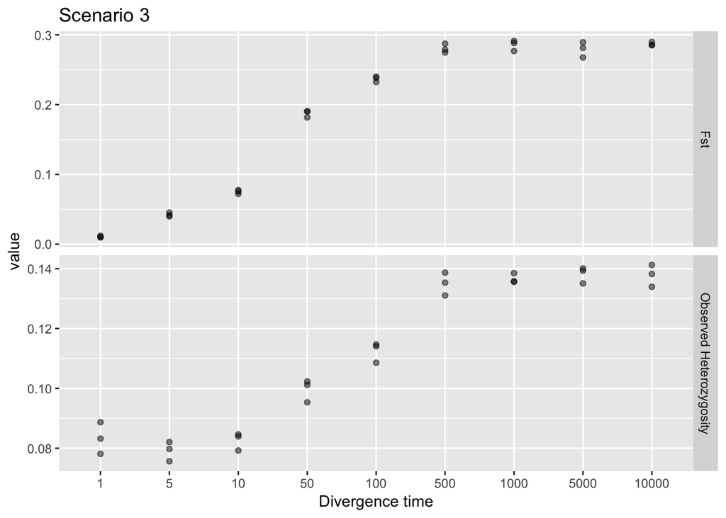

All scenarios had clearly reached equilibrium for both measures by 10,000 generations except observed heterozygosity in scenario 4 (Ne = 500, Nm = 1, theta = 0.1). Thus, it may be worthwhile to increase divergence time to 50,000 or 100,000 just to be sure.

## Fastsimcoal to rmetasim

In order to establish linkage disequilibrium, a few generations of a forward-time simulator were required. rmetasim was parameterized with the same migration rate and population sizes as the fastsimcoal populations. Allele frequencies within populations were independently initialized using the observed allele frequencies from fastsimcoal. rmetasim was parameterized to ensure non-overlapping generations and equal reproductive success for males and females. The Poisson parameter for female and male reproduction was set to 1.2 to attempt to keep the reproductive output of each generation slightly greater than carrying capacity, which was set to Ne. If a population exceeds carrying capacity in any generation, the excess was randomly killed off. A total of 5 rmetasim generations were run to generate the final genotype data.

## Simulated data

The genotype data for each scenario are saved in a separate R workspace .rdata file named “v1.mig.gtypes.#.rdata”, where “mig” is either “island” or “stepping.stone” and “#” is the scenario number. This file contains a single object, `sim.gtypes`, which is a list of 10 gtypes objects from the 10 fastsimcoal replicates based on the parameters of the given scenario. Each fastsimcoal replicate is followed only by a single rmetasim run leading to the present genotype data.

Here is the summary of the first replicate for Scenario 3 with the stepping.stone migration model:

```r
load("v1.sim.data/v1.stepping.stone.gtypes.3.rdata")
sim.gtypes[[1]]
```

```
<<< gtypes created on 2016-12-03 23:53:58 >>>

Contents: 249 samples, 1000 loci, 5 strata

Strata summary:
  num.samples num.missing num.alleles prop.unique.alleles heterozygosity
1          49           0       1.381              0.0295     0.07806122
2          50           0       1.529              0.0355     0.10484000
3          50           0       1.608              0.0215     0.14496000
4          50           0       1.676              0.0345     0.15780000
5          50           0       1.620              0.0120     0.18368000
```

The simulation parameters for a scenario are stored in the attributes of `sim.gtypes` named `params`:

```r
sc <- attr(sim.gtypes, "params")
str(sc)
```

```
List of 12
 $ scenario: int 3
 $ Ne      : num 50
 $ Nm      : num 1
 $ theta   : num 0.1
 $ num.loci: num 1000
 $ mig.rate: num 0.02
 $ mut.rate: num 5e-04
 $ Fst     : num 0.2
 $ div.time: num 1e+05
 $ num.pops: num 5
 $ mig.type: chr "stepping.stone"
 $ mig.mat : num [1:5, 1:5] 0.98 0.02 0 0 0 0.02 0.96 0.02 0 0 ...
```

## Simulation diagnostics

Below are the distributions of mean values of estimates of ldNe, Fst, observed heterozygosity, theta, and minimum allele frequency (MAF) for all scenarios separated by scenario parameter specifications of Nm (rows), theta (columns), and migration matrices (x-axis). Points are randomly jittered in each migration matrix, color-coded by scenario Ne:

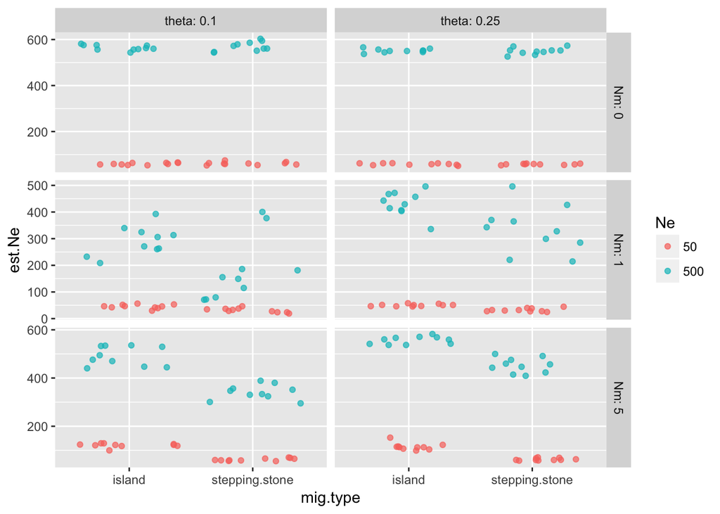

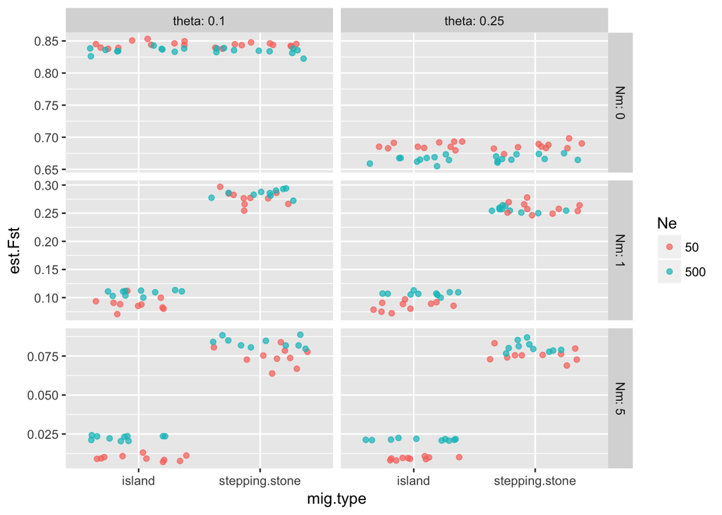

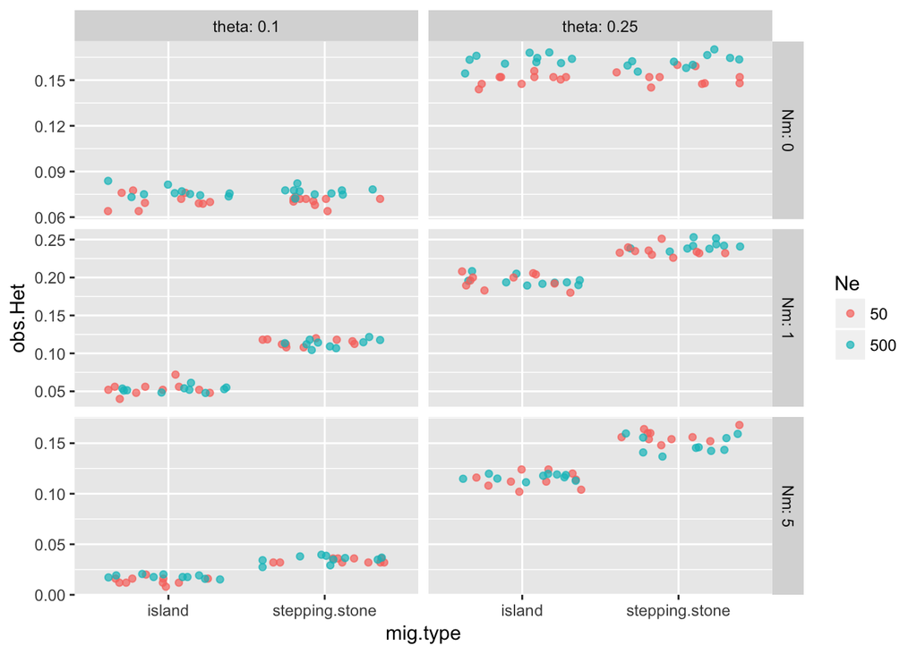

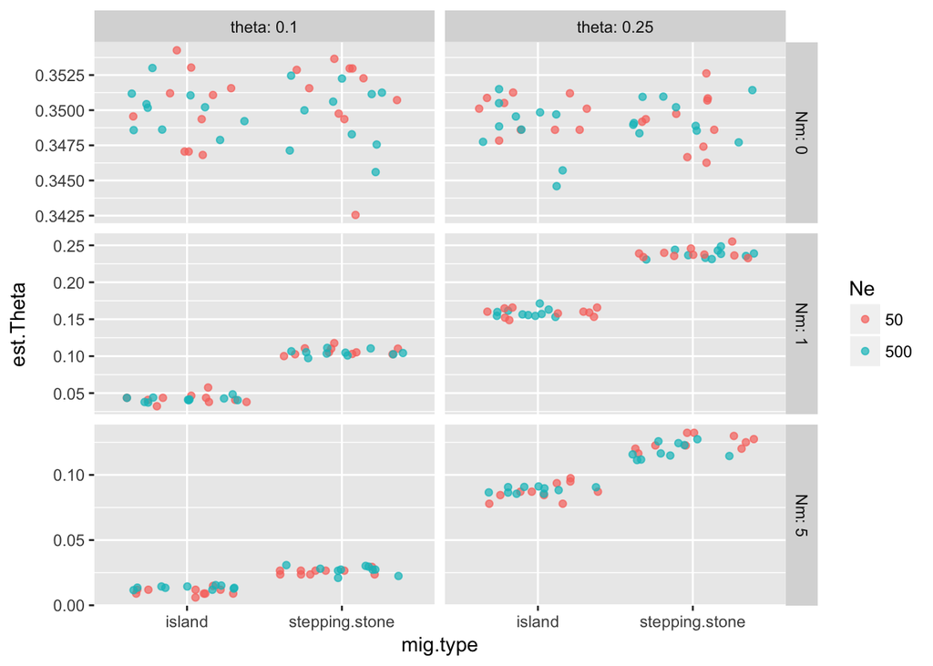

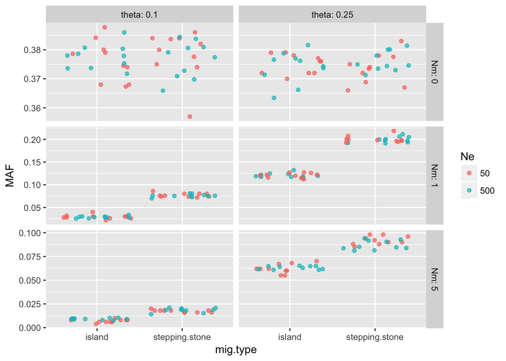